## Course: COMPUTATIONAL THINKING FOR GOVERNANCE ANALYTICS

### Prof. José Manuel Magallanes, PhD

- Visiting Professor of Computational Policy at Evans School of Public Policy and Governance, and eScience Institute Senior Data Science Fellow, University of Washington.
- Professor of Government and Political Methodology, Pontificia Universidad Católica del Perú.

# Session 5: Multivariate Analytics in R (I)

Collect the data we prepared in Python:

```r
link='https://github.com/UWDataScience2020/data/raw/master/hdidemocia.RDS'
# a RDS file from the web needs:
myFile=url(link)

# reading in data:
fromPy=readRDS(file = myFile)

# reset indexes to R format:
row.names(fromPy)=NULL
```

Verifying data structure:

```r
str(fromPy,width = 70,strict.width='cut')
```

```
## 'data.frame':    164 obs. of  16 variables:
##  $ Country                     : chr  "Norway" "Switzerland" "Irela"..
##  $ Humandevelopmentindex       : num  0.954 0.946 0.942 0.939 0.939 ..
##  $ Lifeexpectancyatbirth       : num  82.3 83.6 82.1 81.2 84.7 83.3 ..
##  $ Expectedyearsofschooling    : num  18.1 16.2 18.8 17.1 16.5 22.1 ..
##  $ Meanyearsofschooling        : num  12.6 13.4 12.5 14.1 12 12.7 12..
##  $ Grossnationalincomepercapita: num  68059 59375 55660 46946 60221 ..
##  $ Score                       : num  9.87 9.03 9.24 8.68 6.02 9.09 ..
##  $ Electoralprocessandpluralism: num  10 9.58 10 9.58 3.58 10 10 9.5..
##  $ Functioningofgovernment     : num  9.64 9.29 7.86 8.57 4.36 8.93 ..
##  $ Politicalparticipation      : num  10 7.78 8.33 8.33 6.11 7.78 8...
##  $ Politicalculture            : num  10 9.38 10 7.5 7.5 8.75 10 10 ..
##  $ Civilliberties              : num  9.71 9.12 10 9.41 8.53 10 9.71..
##  $ Regimetype                  : Ord.factor w/ 4 levels "Authoritar"..
##  $ Continent                   : Factor w/ 7 levels "Africa","Asia",..
##  $ countries                   : chr  "Norway" "Switzerland" "Irela"..
##  $ co2_in_MT                   : num  3.98e+07 3.90e+07 3.69e+07 8.4..
```

# Data frames in R

## Querying data frames:

- What is the country with highest HDI?

```r
# you could get more than one
condition1=fromPy$Humandevelopmentindex==max(fromPy$Humandevelopmentindex)
fromPy[condition1,]
```

```
##   Country Humandevelopmentindex Lifeexpectancyatbirth
## 1  Norway                 0.954                  82.3
##   Expectedyearsofschooling Meanyearsofschooling
## 1                     18.1                 12.6
##   Grossnationalincomepercapita Score Electoralprocessandpluralism
## 1                     68058.62  9.87                           10
##   Functioningofgovernment Politicalparticipation Politicalculture
## 1                    9.64                     10               10
##   Civilliberties     Regimetype Continent countries co2_in_MT
## 1           9.71 Full democracy    Europe    Norway  39800000
```

```r
#or
fromPy[condition1,'Country']
```

```
## [1] "Norway"
```

You also have:

```r
# in multiple max, you get only the first one.
fromPy[which.max(fromPy$Humandevelopmentindex),'Country']
```

```
## [1] "Norway"
```

- What is the country with highest HDI in America?

```r
# from AMERICA:
AMERICA=c('South America','North America')
condition2=fromPy$Continent %in% AMERICA
subAmerica=fromPy[condition2,]

subAmerica[condition1,'Country']
```

```
## [1] "Canada"
```

A version using **pipes** and **dplyr**:

```r
library(magrittr)
library(dplyr)
fromPy%>%
    filter(Continent %in% AMERICA)%>%
    filter(Humandevelopmentindex==max(Humandevelopmentindex))%>%
    select(Country)
```

```
##   Country
## 1  Canada
```

- What is the country with highest HDI not from America?

```r
subNotAmerica=fromPy[!condition2,]

subNotAmerica[condition1,'Country']
```

```
## [1] "Norway"
```

A version using **pipes** and **dplyr**:

```r
fromPy%>%
    filter(!Continent %in% AMERICA)%>%
    filter(Humandevelopmentindex==max(Humandevelopmentindex))%>%
    select(Country)
```

```
##   Country
## 1  Norway
```

## Aggregating/summarizing data frames:

- The average HDI per continent:

```r
# the result is a data frame:
aggregate(data=fromPy,Humandevelopmentindex ~ Continent,FUN=mean)
```

```
##       Continent Humandevelopmentindex
## 1        Africa             0.5481400
## 2          Asia             0.7280000
## 3        Europe             0.8692895
## 4   Europe/Asia             0.7974000
## 5 North America             0.7386429
## 6       Oceania             0.7815000
## 7 South America             0.7559167
```

A version using **pipes** and **dplyr**:

```r
fromPy%>%
    group_by(Continent) %>%
    summarise(mean(Humandevelopmentindex))
```

```
## # A tibble: 7 x 2
##   Continent     `mean(Humandevelopmentindex)`
##   <fct>                                 <dbl>
## 1 Africa                                0.548
## 2 Asia                                  0.728
## 3 Europe                                0.869
## 4 Europe/Asia                           0.797
## 5 North America                         0.739
## 6 Oceania                               0.782
## 7 South America                         0.756
```

You can make more complex aggregations that way:

```r
fromPy%>%
    group_by(Continent) %>%
    summarise(meanHDI=mean(Humandevelopmentindex),
              medianHDI=median(Humandevelopmentindex))
```

```
## # A tibble: 7 x 3
##   Continent     meanHDI medianHDI
##   <fct>           <dbl>     <dbl>
## 1 Africa          0.548     0.528
## 2 Asia            0.728     0.723
## 3 Europe          0.869     0.883
## 4 Europe/Asia     0.797     0.806
## 5 North America   0.739     0.756
## 6 Oceania         0.782     0.822
## 7 South America   0.756     0.758
```

- The median of the democracy components:

```r
# several columns in cbind...
aggregate(data=fromPy,
          cbind(Electoralprocessandpluralism,Functioningofgovernment,
                Politicalparticipation,Politicalculture,
                Civilliberties)~Continent,
          FUN=median)
```

```
##       Continent Electoralprocessandpluralism Functioningofgovernment
## 1        Africa                         3.50                   2.895
## 2          Asia                         3.92                   4.290
## 3        Europe                         9.58                   6.965
## 4   Europe/Asia                         2.17                   3.210
## 5 North America                         8.96                   5.715
## 6       Oceania                         8.46                   7.500
## 7 South America                         9.17                   5.360
##   Politicalparticipation Politicalculture Civilliberties
## 1                  4.440            5.315          4.120
## 2                  4.440            5.000          4.120
## 3                  6.670            6.880          8.530
## 4                  5.000            4.380          3.530
## 5                  6.110            5.315          7.060
## 6                  6.945            6.880          8.825
## 7                  5.835            5.000          7.650
```

If you know the indexes of the columns:

```r
# In ".~ Continent" the dot represents all the other variables
aggregate(data=fromPy[,c(8:12,14)],.~Continent,FUN=median)
```

```
##       Continent Electoralprocessandpluralism Functioningofgovernment
## 1        Africa                         3.50                   2.895
## 2          Asia                         3.92                   4.290
## 3        Europe                         9.58                   6.965
## 4   Europe/Asia                         2.17                   3.210
## 5 North America                         8.96                   5.715
## 6       Oceania                         8.46                   7.500
## 7 South America                         9.17                   5.360
##   Politicalparticipation Politicalculture Civilliberties
## 1                  4.440            5.315          4.120
## 2                  4.440            5.000          4.120
## 3                  6.670            6.880          8.530
## 4                  5.000            4.380          3.530
## 5                  6.110            5.315          7.060
## 6                  6.945            6.880          8.825
## 7                  5.835            5.000          7.650
```

A version using **pipes** and **dplyr**:

```r
fromPy[,c(8:12,14)]%>%
    group_by(Continent) %>%
    summarise_all(list(median))
```

```
## # A tibble: 7 x 6
##   Continent Electoralproces… Functioningofgo… Politicalpartic…
##   <fct>                <dbl>            <dbl>            <dbl>
## 1 Africa                3.5              2.90             4.44
## 2 Asia                  3.92             4.29             4.44
## 3 Europe                9.58             6.96             6.67
## 4 Europe/A…             2.17             3.21             5
## 5 North Am…             8.96             5.72             6.11
## 6 Oceania               8.46             7.5              6.94
## 7 South Am…             9.17             5.36             5.84
## # … with 2 more variables: Politicalculture <dbl>, Civilliberties <dbl>
```

A more complex version:

```r
fromPy[,c(8:12,14)]%>%
    group_by(Continent) %>%
    summarise_all(list(MIN=min,MAX=max))
```

```
## # A tibble: 7 x 11
##   Continent Electoralproces… Functioningofgo… Politicalpartic…
##   <fct>                <dbl>            <dbl>            <dbl>
## 1 Africa                0                0                1.11
## 2 Asia                  0                0                1.67
## 3 Europe                0.92             2                2.78
## 4 Europe/A…             0.5              1.79             2.78
## 5 North Am…             0                2.07             3.33
## 6 Oceania               6.58             5.36             3.89
## 7 South Am…             0                1.79             5
## # … with 7 more variables: Politicalculture_MIN <dbl>,
## #   Civilliberties_MIN <dbl>, Electoralprocessandpluralism_MAX <dbl>,
## #   Functioningofgovernment_MAX <dbl>, Politicalparticipation_MAX <dbl>,
## #   Politicalculture_MAX <dbl>, Civilliberties_MAX <dbl>
```

## Creating new data:

One column:

```r
# HDIdico is the new variable:
# 1 if the value is < median, ) otherwise.
fromPy$HDIdico=ifelse(fromPy$Humandevelopmentindex>
                          median(fromPy$Humandevelopmentindex),
                      1,0)
# then:
head(fromPy)
```

```
##       Country Humandevelopmentindex Lifeexpectancyatbirth
## 1      Norway                 0.954                  82.3
## 2 Switzerland                 0.946                  83.6
## 3     Ireland                 0.942                  82.1
## 4     Germany                 0.939                  81.2
## 5   Hong Kong                 0.939                  84.7
## 6   Australia                 0.938                  83.3
##   Expectedyearsofschooling Meanyearsofschooling
## 1                     18.1                 12.6
## 2                     16.2                 13.4
## 3                     18.8                 12.5
## 4                     17.1                 14.1
## 5                     16.5                 12.0
## 6                     22.1                 12.7
##   Grossnationalincomepercapita Score Electoralprocessandpluralism
```

[output cut: 20 more lines]

A version using **pipes** and **dplyr**:

```r
# you will add a new column at the end (this is a preview):
fromPy%>%
    mutate(HDIdico =ifelse(Humandevelopmentindex >
                           median(Humandevelopmentindex),
                           1, 0))%>%head()
```

```
##       Country Humandevelopmentindex Lifeexpectancyatbirth
## 1      Norway                 0.954                  82.3
## 2 Switzerland                 0.946                  83.6
## 3     Ireland                 0.942                  82.1
## 4     Germany                 0.939                  81.2
## 5   Hong Kong                 0.939                  84.7
## 6   Australia                 0.938                  83.3
##   Expectedyearsofschooling Meanyearsofschooling
## 1                     18.1                 12.6
## 2                     16.2                 13.4
## 3                     18.8                 12.5
## 4                     17.1                 14.1
## 5                     16.5                 12.0
## 6                     22.1                 12.7
##   Grossnationalincomepercapita Score Electoralprocessandpluralism
```

[output cut: 20 more lines]

# Unsupervised ML: Clustering Techniques

1. Partitioning: You will request a particular number of clusters to the algorithm. The algorithm will put every case in one of those clusters. Outliers will affect output.

[figure not shown]

Source: https://en.wikipedia.org/wiki/Cluster_analysis

2. Hierarchizing: You will ask the algorithm to find all possible ways cases can be clustered, individually and in subgroups following a tree-construction/deconstruction approach. You should determine the right amount of clusters.Outliers will affect output.

3. Based on Density

This approach will cluster cases as long as they are close to each other at a predetermined distance. You need to input the distance and the minimal amount of cases in a neighboorhood to be considered a cluster. The algorithm is not affected by outliers.

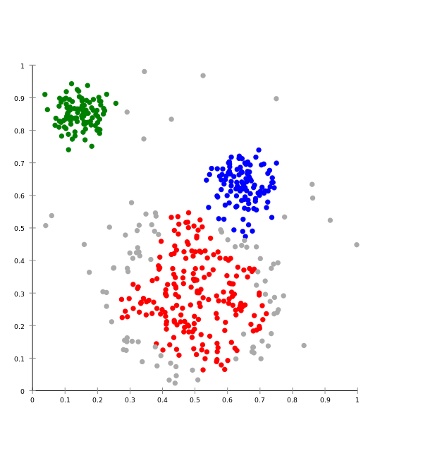

https://commons.wikimedia.org/wiki/Cluster_analysis

For all cases, you need the DISTANCE MATRIX:

**a.** Subset the data frame:

```r
dfClus=fromPy[,c(2,12,13)]
```

**b.** Rename the rows:

```r
row.names(dfClus)=fromPy$Country
head(dfClus)
```

```
##             Humandevelopmentindex Civilliberties       Regimetype
## Norway                      0.954           9.71   Full democracy
## Switzerland                 0.946           9.12   Full democracy
## Ireland                     0.942          10.00   Full democracy
## Germany                     0.939           9.41   Full democracy
## Hong Kong                   0.939           8.53 Flawed democracy
## Australia                   0.938          10.00   Full democracy
```

**c.** Keep only complete data:

```r
dfClus=dfClus[complete.cases(dfClus),]
```

**d.** Set random seed:

```r
set.seed(999)
```

**e.** Decide distance method and compute distance matrix:

```r
library(cluster)
dfClus_D=cluster::daisy(x=dfClus,metric="gower")
```

## Partitioning technique

### 1. Apply function: you need to indicate the amount of clusters required.

```r
NumCluster=4
res.pam = pam(x=dfClus_D,k = NumCluster,cluster.only = F)
```

### 2. Save clustering results.

```r
dfClus$pam=as.factor(res.pam$clustering)
```

You can see who the members are:

```r
row.names(dfClus[dfClus$pam==1,])
```

```
##  [1] "Norway"         "Switzerland"    "Ireland"        "Germany"
##  [5] "Australia"      "Iceland"        "Sweden"         "Netherlands"
##  [9] "Denmark"        "Finland"        "Canada"         "New Zealand"
## [13] "United Kingdom" "Austria"        "Luxembourg"     "Spain"
## [17] "France"         "Portugal"       "Chile"          "Uruguay"
## [21] "Mauritius"      "Costa Rica"
```

You can request belonging:

```r
dfClus[row.names(dfClus)=="Peru",'pam']
```

```
## [1] 2
## Levels: 1 2 3 4
```

### 3. Evaluate Results.

**3.a** Global and visual report

```r
library(factoextra)
```

```
##   cluster size ave.sil.width
## 1       1   22          0.81
## 2       2   53          0.50
## 3       3   52          0.53
## 4       4   37          0.48
```

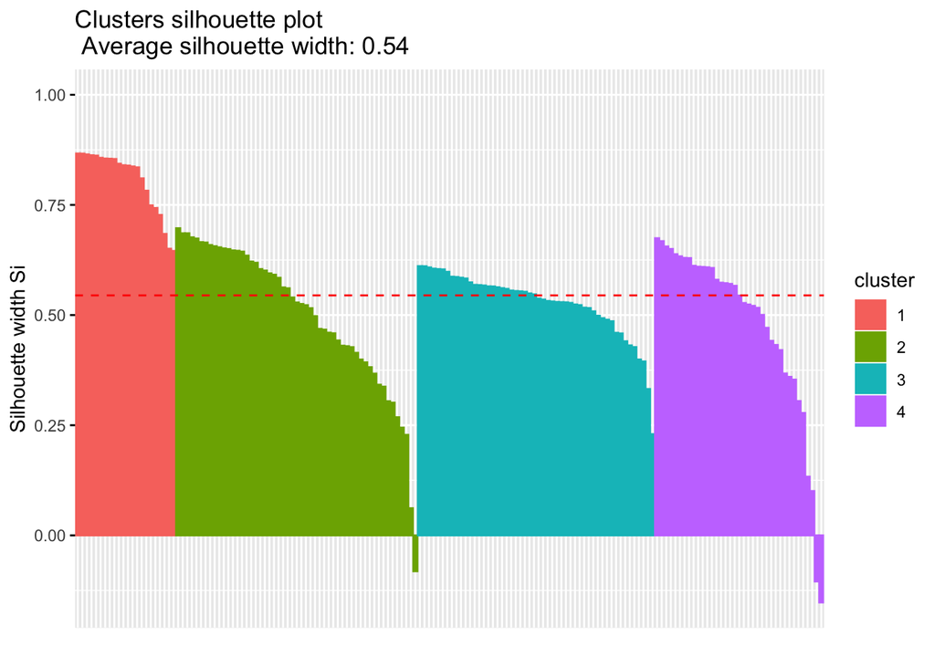

```r
fviz_silhouette(res.pam)
```

**3.b** Individual report

```r
pamEval=data.frame(res.pam$silinfo$widths)
head(pamEval)
```

```
##            cluster neighbor sil_width
## Finland          1        2 0.8666174
## Canada           1        2 0.8664292
## Sweden           1        2 0.8646923
## Germany          1        2 0.8627143
## Iceland          1        2 0.8618794
## Luxembourg       1        2 0.8569559
```

**3.c** Detecting anomalies

```r
pamEval[pamEval$sil_width<0,]
```

```
##            cluster neighbor   sil_width
## Montenegro       2        4 -0.08135866
## Lesotho          4        2 -0.10457914
## Ghana            4        2 -0.15217822
```

## Hierarchizing: agglomerative

### 1. Apply function: you need to indicate the amount of clusters required.

```r
library(factoextra)

res.agnes<- hcut(dfClus_D, k = NumCluster,isdiss=T,
                 hc_func='agnes',
                 hc_method = "ward.D2")
```

### 2. Save clustering results.

```r
dfClus$agn=as.factor(res.agnes$cluster)
```

You can see who are the members:

```r
row.names(dfClus[dfClus$agn==1,])
```

```
##  [1] "Norway"         "Switzerland"    "Ireland"        "Germany"
##  [5] "Australia"      "Iceland"        "Sweden"         "Netherlands"
##  [9] "Denmark"        "Finland"        "Canada"         "New Zealand"
## [13] "United Kingdom" "Austria"        "Luxembourg"     "Spain"
## [17] "France"         "Portugal"       "Chile"          "Uruguay"
## [21] "Mauritius"      "Costa Rica"
```

You can request belonging:

```r
dfClus[row.names(dfClus)=="Peru",'agn']
```

```
## [1] 2
## Levels: 1 2 3 4
```

### 3. Evaluate Results.

**3.a** Global and visual report

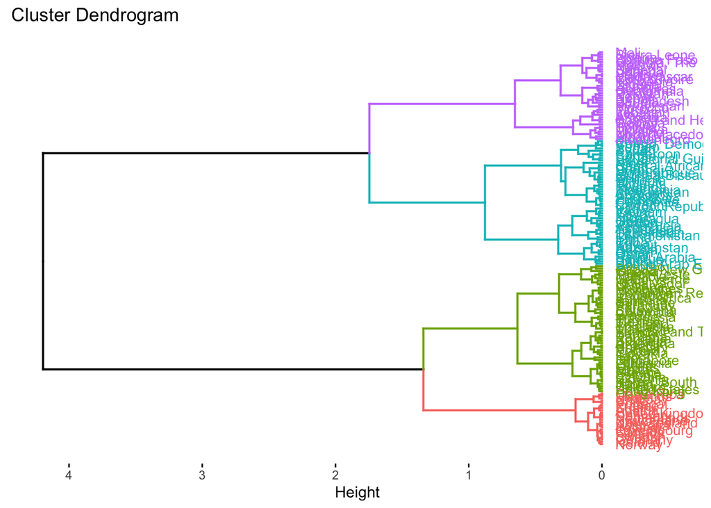

```r
fviz_dend(res.agnes,k=NumCluster, cex = 0.7, horiz = T)
```

```
##   cluster size ave.sil.width
## 1       1   22          0.81
## 2       2   53          0.51
## 3       3   52          0.52
## 4       4   37          0.50
```

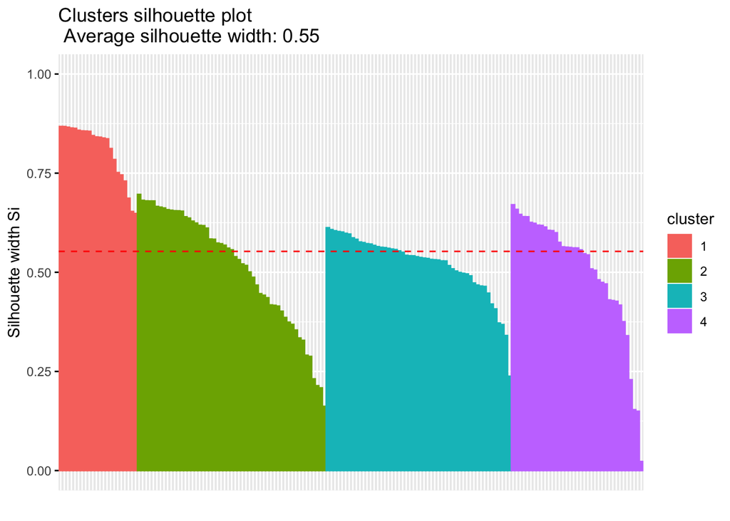

```r
library(factoextra)
fviz_silhouette(res.agnes)
```

**3.b** Individual report

```r
agnEval=data.frame(res.agnes$silinfo$widths)
head(agnEval)
```

```
##            cluster neighbor sil_width
## Finland          1        2 0.8676881
## Canada           1        2 0.8675080
## Sweden           1        2 0.8657933
## Germany          1        2 0.8638267
## Iceland          1        2 0.8629592
## Luxembourg       1        2 0.8581401
```

**3.c** Detecting anomalies

```r
agnEval[agnEval$sil_width<0,]
```

```
## [1] cluster   neighbor  sil_width
## <0 rows> (or 0-length row.names)
```

## Hierarchizing: divisive

### 1. Apply function: you need to indicate the amount of clusters required.

```r
library(factoextra)

res.diana<- hcut(dfClus_D, k = NumCluster,
                 hc_func='diana',
                 hc_method = "ward.D")
```

## Density-based clustering

```r
library(fpc)

res.db = dbscan(dfClus_D, eps=0.05, MinPts=15,method = 'dist')
```

How many cluster were produced? and How many outliers are there?

```r
# '0' identifies outliers:
res.db
```

```
## dbscan Pts=164 MinPts=15 eps=0.05
##          0  1  2
## border 104  7 26
## seed     0 12 15
## total  104 19 41
```

Save result:

```r
dfClus$db=as.factor(res.db$cluster)
```

# How to compare clustering?

- Prepare a bidimensional map:

```r
projectedData = cmdscale(dfClus_D, k=2,add = T)
dfClus$dim1 <- projectedData$points[,1]
dfClus$dim2 <- projectedData$points[,2]
```

- See the map:

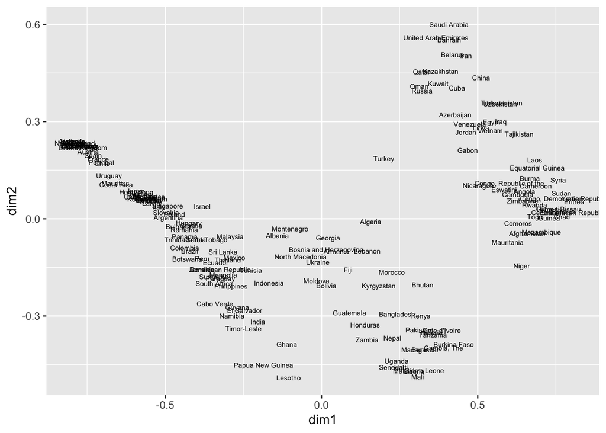

```r
base= ggplot(data=dfClus,
             aes(x=dim1, y=dim2,
                 label=row.names(dfClus)))
base + geom_text(size=2)
```

- Plot results from PAM:

```r
pam=base + labs(title = "PAM") + geom_point(size=2,
                                              aes(color=pam),
                                              show.legend = F)
```

- Plot results from Hierarchical AGNES:

```r
agn=base + labs(title = "AGNES") + geom_point(size=2,
                                              aes(color=agn),
                                              show.legend = F)
```

Compare visually:

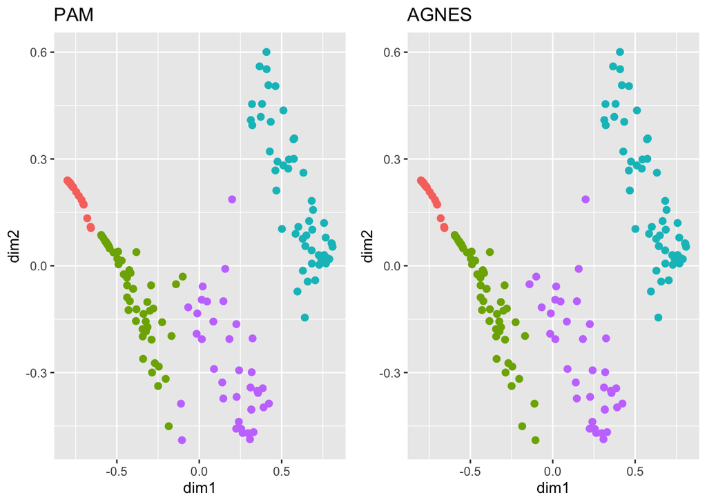

```r
library(ggpubr)
ggarrange(pam, agn)
```

- Plot results from DBSCAN:

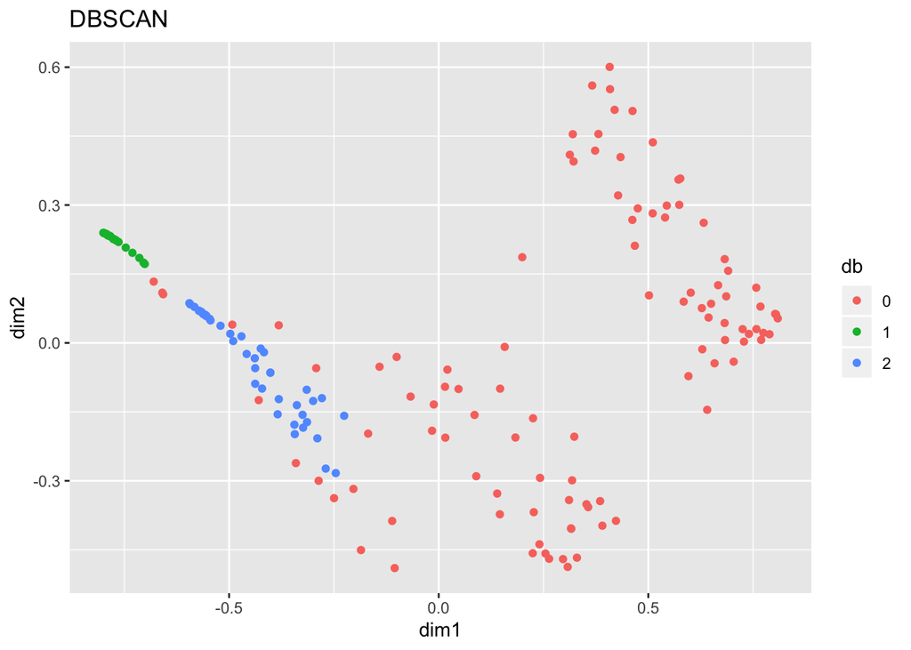

```r
db= base + labs(title = "DBSCAN") + geom_point(aes(color=db),
                                               show.legend = T)
db
```

Annotating:

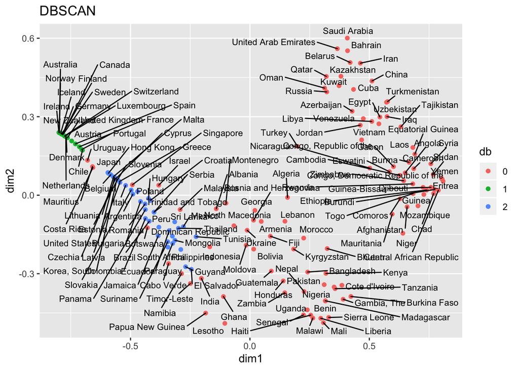

```r
library(ggrepel)
db + geom_text_repel(size=3,aes(label=row.names(dfClus)))
```

Annotating outliers:

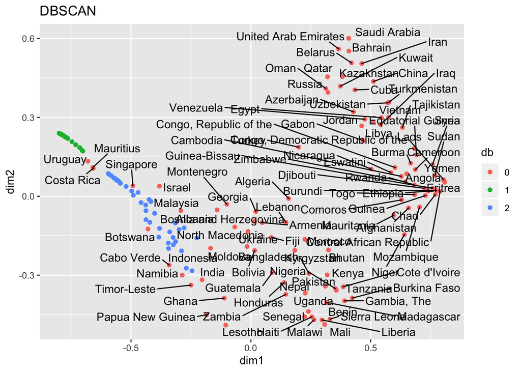

```r
LABEL=ifelse(dfClus$db==0,row.names(dfClus),"")

db + geom_text_repel(aes(label=LABEL))
```